# In-class Activity: NYC Flights

## Spatial Data

Let’s read in some spatial data using the `rnaturalearth` package. Review the maps activity and slides for a refresher. Specifically, we want the continental 48 states and the world at medium scale. We’ll also extract the bounding box for our new object called `states48` for easier plotting.

```r
states48 <- ne_states(iso_a2 = 'US', returnclass = "sf") %>%
  filter(name != "Hawaii" & name != "Alaska")

world <- ne_countries(scale = "medium", returnclass = "sf")

my_bbox <- st_bbox(states48)
```

#### Problem 1: Mapping the number of flights by destination.

Using the `flights` and `airports` tables, create a new data set called `airports_n` that includes the number of flights to each destination and all the airport metadata from the `airports` table (including `lat` adn `lon`).

| dest | n | name | lat | lon | alt | tz | dst | tzone |
| --- | --- | --- | --- | --- | --- | --- | --- | --- |
| ABQ | 254 | Albuquerque International Sunport | 35.04022 | -106.60919 | 5355 | -7 | A | America/Denver |
| ACK | 265 | Nantucket Mem | 41.25305 | -70.06018 | 48 | -5 | A | America/New_York |
| ALB | 439 | Albany Intl | 42.74827 | -73.80169 | 285 | -5 | A | America/New_York |
| ANC | 8 | Ted Stevens Anchorage Intl | 61.17436 | -149.99636 | 152 | -9 | A | America/Anchorage |
| ATL | 17215 | Hartsfield Jackson Atlanta Intl | 33.63672 | -84.42807 | 1026 | -5 | A | America/New_York |
| AUS | 2439 | Austin Bergstrom Intl | 30.19453 | -97.66989 | 542 | -6 | A | America/Chicago |

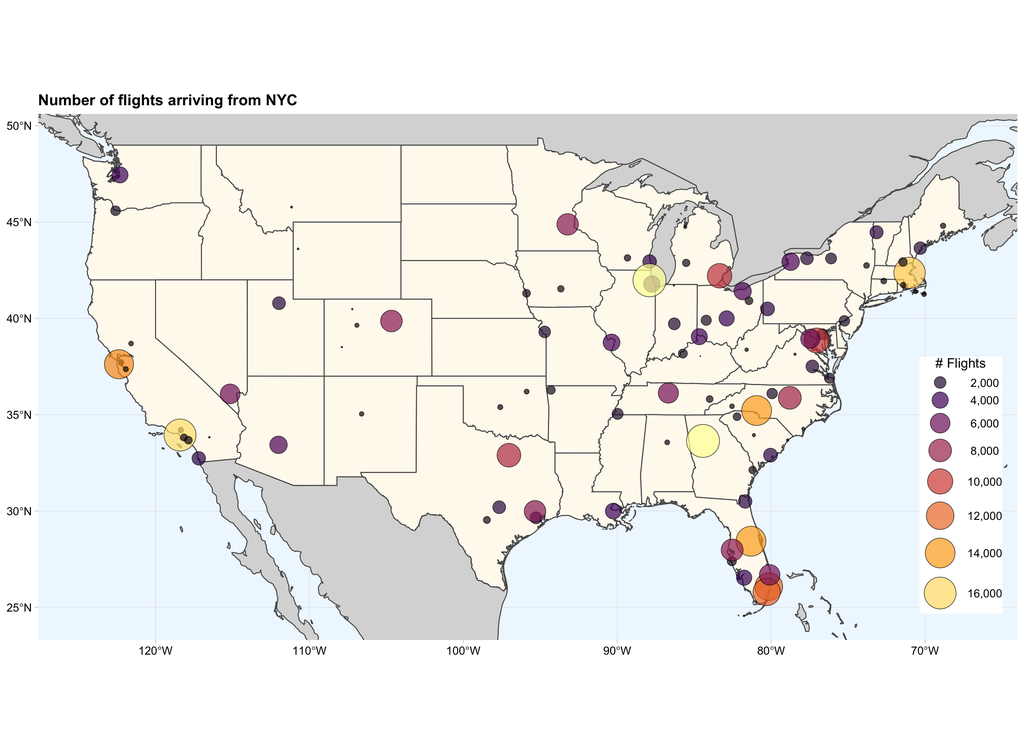

#### Problem 2: Mapping average arrival delays for flights from NYC.

Using the `flights` and `airports` tables, create a new data set called `avg_delay` that calculates the average arrival delay (`arr_delay`) then bring in all the airport metadata from the `airports` table (including `lat` adn `lon`).

| dest | mean_delay | name | lat | lon | alt | tz | dst | tzone |
| --- | --- | --- | --- | --- | --- | --- | --- | --- |
| ABQ | 4.381890 | Albuquerque International Sunport | 35.04022 | -106.60919 | 5355 | -7 | A | America/Denver |
| ACK | 4.852273 | Nantucket Mem | 41.25305 | -70.06018 | 48 | -5 | A | America/New_York |
| ALB | 14.397129 | Albany Intl | 42.74827 | -73.80169 | 285 | -5 | A | America/New_York |
| ANC | -2.500000 | Ted Stevens Anchorage Intl | 61.17436 | -149.99636 | 152 | -9 | A | America/Anchorage |
| ATL | 11.300113 | Hartsfield Jackson Atlanta Intl | 33.63672 | -84.42807 | 1026 | -5 | A | America/New_York |
| AUS | 6.019909 | Austin Bergstrom Intl | 30.19453 | -97.66989 | 542 | -6 | A | America/Chicago |

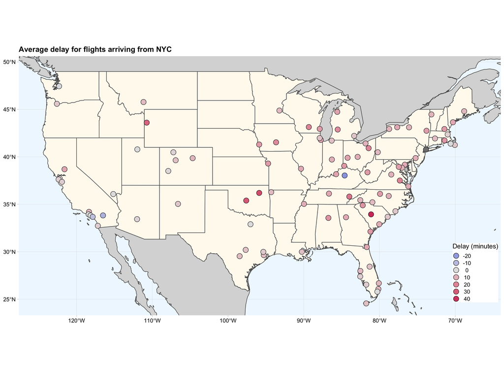

#### Problem 3: Mapping 100 routes at random.

In this activity, we want to draw (approximately) the route each plane flies from its origin to its destination for the 100 flights drawn randomly from the entire set. We want to color these routes by the carrier’s full name (e.g., “Delta Air Lines Inc.”). What variables would you need? What tables would you need to combine?

Let’s call this new data set `rand_flights`. Use the `dplyr` function `sample_n()` to select 100 rows at random.

```
## Observations: 100
## Variables: 24
## $ year           <int> 2013, 2013, 2013, 2013, 2013, 2013, 2013, 2013, 2…
## $ month          <int> 10, 5, 5, 5, 8, 5, 1, 11, 6, 4, 6, 4, 12, 9, 12, …
## $ day            <int> 13, 18, 13, 18, 11, 24, 4, 25, 3, 9, 13, 20, 13, …
## $ dep_time       <int> 855, 1022, 1806, 1800, 1711, 1828, 1514, 656, 131…
## $ sched_dep_time <int> 900, 1021, 1803, 1725, 1710, 1825, 1517, 700, 131…
## $ dep_delay      <dbl> -5, 1, 3, 35, 1, 3, -3, -4, -2, -8, -2, 9, -1, -5…
## $ arr_time       <int> 1116, 1224, 1909, 1857, 1940, 2125, 1820, 951, 15…
## $ sched_arr_time <int> 1144, 1243, 1940, 1855, 1927, 2146, 1811, 1015, 1…
## $ arr_delay      <dbl> -28, -19, -31, 2, 13, -21, 9, -24, 11, 3, 18, -7,…
## $ carrier        <chr> "DL", "DL", "UA", "WN", "UA", "UA", "B6", "B6", "…
## $ flight         <int> 1747, 1529, 691, 1256, 485, 1075, 537, 23, 1014, …
## $ tailnum        <chr> "N982DL", "N385DN", "N559UA", "N773SA", "N412UA",…
## $ origin         <chr> "LGA", "JFK", "LGA", "EWR", "EWR", "EWR", "EWR", …
## $ dest           <chr> "ATL", "LAS", "ORD", "BNA", "DEN", "SNA", "TPA", …
## $ air_time       <dbl> 109, 281, 102, 98, 223, 332, 156, 330, 100, 108, …
## $ distance       <dbl> 762, 2248, 733, 748, 1605, 2434, 997, 2475, 529, …
## $ hour           <dbl> 9, 10, 18, 17, 17, 18, 15, 7, 13, 16, 8, 14, 16, …
## $ minute         <dbl> 0, 21, 3, 25, 10, 25, 17, 0, 15, 30, 0, 10, 0, 59…
## $ time_hour      <dttm> 2013-10-13 09:00:00, 2013-05-18 10:00:00, 2013-0…
## $ origin_lat     <dbl> 40.77725, 40.63975, 40.77725, 40.69250, 40.69250,…
## $ origin_lon     <dbl> -73.87261, -73.77893, -73.87261, -74.16867, -74.1…
## $ dest_lat       <dbl> 33.63672, 36.08006, 41.97860, 36.12447, 39.86166,…
## $ dest_lon       <dbl> -84.42807, -115.15225, -87.90484, -86.67819, -104…
## $ name           <chr> "Delta Air Lines Inc.", "Delta Air Lines Inc.", "…
```

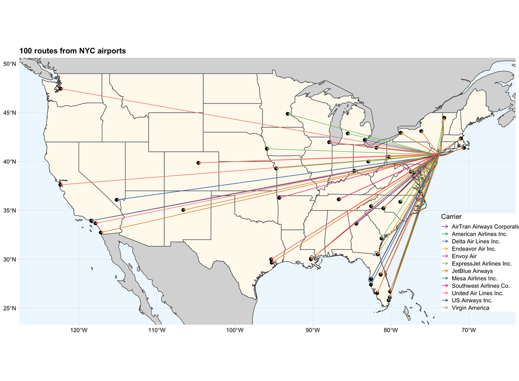